# Introduction to ggmuller

Ggmuller is an attempt to set an easy-to-use standard for representing evolutionary dynamics as stacked area plots that combine information about frequency dynamics and phylogeny. The horizontal axis is time, and shapes of different colours represent genotypes (or other subtypes), with height corresponding to genotype frequency (or relative abundance) at the corresponding time point. Descendant genotypes are shown emerging from inside their parents.

Such diagrams are sometimes termed Muller plots in honour of Hermann Joseph Muller, who [used them in 1932](http://www.jstor.org/stable/2456922) to illustrate an evolutionary advantage of sex. More recently, they can be seen in experimental evolution papers by Richard Lenski, Jeffrey Barrick and others, and in many cancer evolution reviews.

## How does it work?

The core function is `get_Muller_df`, which constructs a specially ordered data frame from which we can draw a stacked area plot. `get_Muller_df` takes two data frames as input: first an adjacency matrix that defines a phylogeny (with columns named “Identity” and “Parent”), and second the populations of each genotype over time (with columns named “Identity”, “Generation” and “Population”). The genotype names in the “Identity” and “Parent” columns can be any words or numbers. You can use a phylo object instead of an adjacency matrix, provided the genotype names in the population data are integers that correspond to the node numbers in the phylo object.

`get_Muller_df` records a path through the phylogenetic tree. Each genotype appears exactly twice in the path: once before and once after all of the genotype’s descendants. The function then associates each instance of each genotype with half of the genotype’s frequency over time.

To draw plots, ggmuller exploits Hadley Wickham’s [ggplot](http://ggplot2.org/) package (which accounts for the first part of its name). Because the two instances of each genotypes are coloured identically, the resulting plot shows each genotype emerging from the centre of its parent (following Jeffrey Barrick’s example, multiple descendants are stacked from top to bottom in chronological order of appearance).

## Basic usage: frequencies

If your adjacency matrix and your population data frame are properly formatted, you can use ggmuller to visualize your results with just two lines of R code:

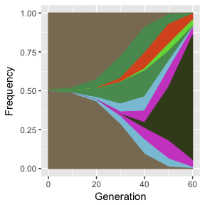

```r
library(ggmuller)
Muller_df <- get_Muller_df(example_edges, example_pop_df)
Muller_plot(Muller_df)
```

Simply replace `example_edges` and `example_pop_df` with the names of the data frames that contain your adjacency matrix and population data, respectively.

## Basic usage: population sizes

Whereas `Muller_plot` shows frequencies, the sister function `Muller_pop_plot` shows changes in population sizes. Plots of this type are commonly used to show how evolutionary dynamics respond to environmental change, such as in a tumour during chemotherapy. Using the same example data as before:

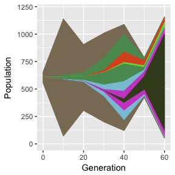

```r
Muller_df <- get_Muller_df(example_edges, example_pop_df)
Muller_pop_plot(Muller_df)
```

That’s all you need for basic usage. The rest of this tutorial introduces some additional features and options.

## A more detailed example

Most of the code that follows is to create an appropriate data set. First we make an adjacency matrix that defines the phylogeny. In this example, the phylogeny is branched such that clone_A begets clone_B and clone_C, then clone_B begets clone_D and clone_E, etc.

```r
edges3 <- data.frame(Parent = paste0("clone_",
 LETTERS[c(rep(1:3, each = 2), 2, 5)]),
 Identity = paste0("clone_", LETTERS[2:9]))
```

Next we construct a data frame of genotype populations over time. Here the population data are generated using diverse fitness values:

```r
# a function for generating exponential growth curves:
pop_seq <- function(gens, lambda, start_gen) c(rep(0, start_gen),
                                               exp(lambda * gens[0:(length(gens) - start_gen)]))
lambda <- 0.1 # baseline fitness
gens <- 0:150 # time points
fitnesses <- c(1, 2, 2.2, 2.5, 3, 3.2, 3.5, 3.5, 3.8) # relative fitnesses of genotypes
pop3 <- data.frame(Generation = rep(gens, 9),
 Identity = paste0("clone_", LETTERS[rep(1:9, each = length(gens))]),
 Population = c(1E2 * pop_seq(gens, fitnesses[1]*lambda, 0),
 pop_seq(gens, fitnesses[2]*lambda, 0),
 pop_seq(gens, fitnesses[3]*lambda, 10),
 pop_seq(gens, fitnesses[4]*lambda, 20),
 pop_seq(gens, fitnesses[5]*lambda, 30),
 pop_seq(gens, fitnesses[6]*lambda, 40),
 pop_seq(gens, fitnesses[7]*lambda, 50),
 pop_seq(gens, fitnesses[8]*lambda, 50),
 pop_seq(gens, fitnesses[9]*lambda, 60)),
 Fitness = rep(fitnesses, each = length(gens)))
```

Of course there are more concise ways to create this data frame, but the long-winded version makes the data more visible in the code. Note the inclusion of an optional “Fitness” column containing the fitness values. We combine the data using `get_Muller_df` as before:

```r
Muller_df3 <- get_Muller_df(edges3, pop3)
```

We create two versions of the plot. The first version is coloured by genotype identity (the default) and has customised axis labels and a legend:

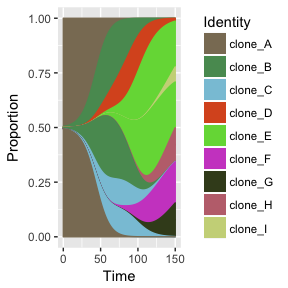

```r
Muller_plot(Muller_df3, add_legend = TRUE, xlab = "Time", ylab = "Proportion")
```

The second version is (using the RColorBrewer package) coloured by fitness, making use of that extra column:

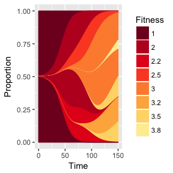

```r
library(RColorBrewer)
num_cols <- length(unique(Muller_df3$Fitness)) + 1
Muller_df3$Fitness <- as.factor(Muller_df3$Fitness)
Muller_plot(Muller_df3, colour_by = "Fitness",
 palette = rev(colorRampPalette(brewer.pal(9, "YlOrRd"))(num_cols)),
 add_legend = TRUE, xlab = "Time", ylab = "Proportion")
```

Since simulations can result in very large sets of genotypes, many of which never become abundant, `get_Muller_df` has a threshold option to exclude rarities:

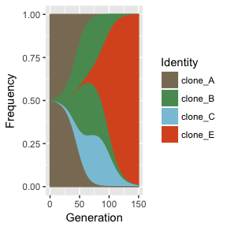

```r
Muller_df3_censored <- get_Muller_df(edges3, pop3, threshold = 0.1)
Muller_plot(Muller_df3_censored, add_legend = TRUE)
```

## Further customisation with ggplot

`Muller_plot` is basically a wrapper for ggplot and you may prefer to call ggplot directly to enable further plot customisation. For example:

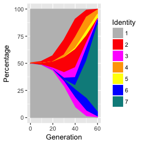

```r
library(ggplot2)
my_palette <- c("grey", "red", "magenta", "orange", "yellow", "blue", "darkcyan")
ggplot(Muller_df, aes_string(x = "Generation", y = "Frequency", group = "Group_id", fill = "Identity", colour = "Identity")) +
    geom_area() +
    theme(legend.position = "right") +
    guides(linetype = FALSE, color = FALSE) +
    scale_y_continuous(labels = 25 * (0:4), name = "Percentage") +
    scale_fill_manual(name = "Identity", values = my_palette) +
    scale_color_manual(values = my_palette)
```

You can also use ggplot to produce population plots, but only after using the `add_empty_pop` function to modify the input data.

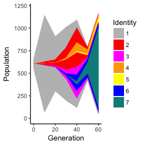

```r
Muller_df_pop <- add_empty_pop(Muller_df)
id_list <- sort(unique(Muller_df_pop$Identity)) # list of legend entries, omitting NA
ggplot(Muller_df_pop, aes_string(x = "Generation", y = "Population", group = "Group_id", fill = "Identity", colour = "Identity")) +
  geom_area() +
  theme(legend.position = "right") +
  guides(linetype = FALSE, color = FALSE) +
  scale_fill_manual(name = "Identity", values = my_palette, breaks = id_list) +
  scale_color_manual(values = my_palette) +
  theme_classic()
```

## Converting between adjacency matrix and phylo representations

We can visualize the tree from our previous example using Emmanuel Paradis’ [ape](http://ape-package.ird.fr/) package, but first we need to use the ggmuller function `adj_matrix_to_tree` to convert our adjacency matrix (with arbitrary node names) to a phylo object that ape can understand. Phylo is the standard way of representing trees in R, and it requires nodes to be numbered in a particular order.

```r
tree <- adj_matrix_to_tree(edges3)
```

After optionally labeling the nodes, we use ape’s `plot.phylo` function to draw the tree:

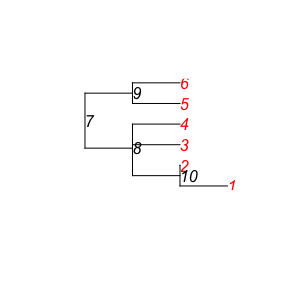

```r
library(ape)
tree$tip.label <- 1:length(tree$tip.label) # optional
tree$node.label <- (length(tree$tip.label) + 1):10 # optional
plot(tree, show.node.label = TRUE, show.tip.label = TRUE, tip.color = "red")
```

If you already have a tree in phylo format, you can use that instead of an adjacency matrix as input to `get_Muller_df`, as long as the genotype names in the population data are integers that correspond to the node numbers in the phylo object.